# Measuring partisan segregation in political media consumption

April 12, 2021

## Problem

- Lots of talk about “echo chambers”
  - Surely this is a continuous phenomenon
  - Segregation a clearer concept
- Segregation in this context = different media diets by partisanship
- Related to but distinct from selective exposure theory
  - Interest in *how much* segregation, not *why* there is segregation
- How do you measure this?

## What I am presenting

- Using study of segregation as an approach this problem
  - Residential (racial) segregation
- Focusing on people as unit of analysis
  - Rather than (just) sources or audiences
- Goal: a number that could be plugged into a regression model

## What I am presenting

A measure that…

- Can describe *people*
  - Person X has Y level of segregation
- Accommodates multi-party systems
- Is comparable across contexts
  - parties, countries, non-media contexts
- Requires no more complex designs than usual

## Spectral Segregation Index (SSI)

Requires a network/graph representation

For people:

- Nodes are people, edges reflect co-consumption
- Weight of edges = # of shared sources

For sources:

- Nodes are sources, edges reflect co-consumers
- Weight of edges = # of pairs of people who both use source

## Data

Pew Research Center’s American Trends Panel, Wave 1 (2014)

- N = 3,308
- Represenative of adults in USA
- 66 political media sources
  - Mix of TV, internet, print, radio (some overlapping)
  - Did you get news from in the past week? (Yes/No)
  - About 5 sources per respondent
- Sources coded as left/Democrat-favoring, right/Republican-favoring, or non-partisan
- Respondents self-report partisanship

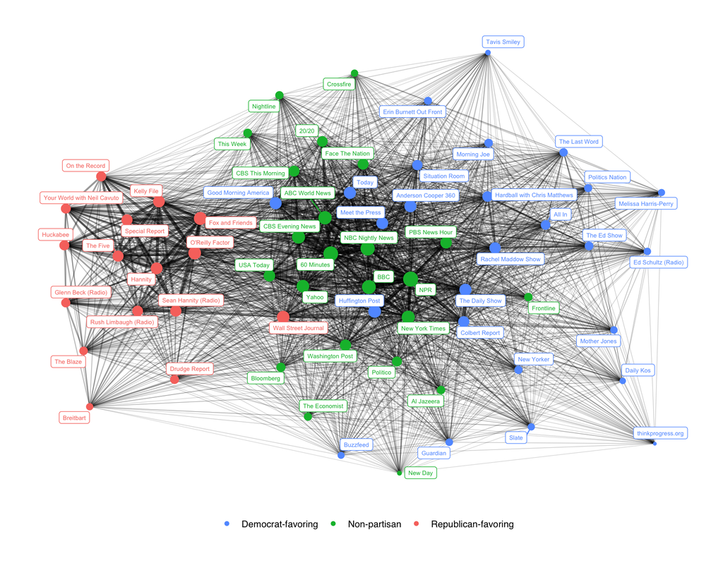

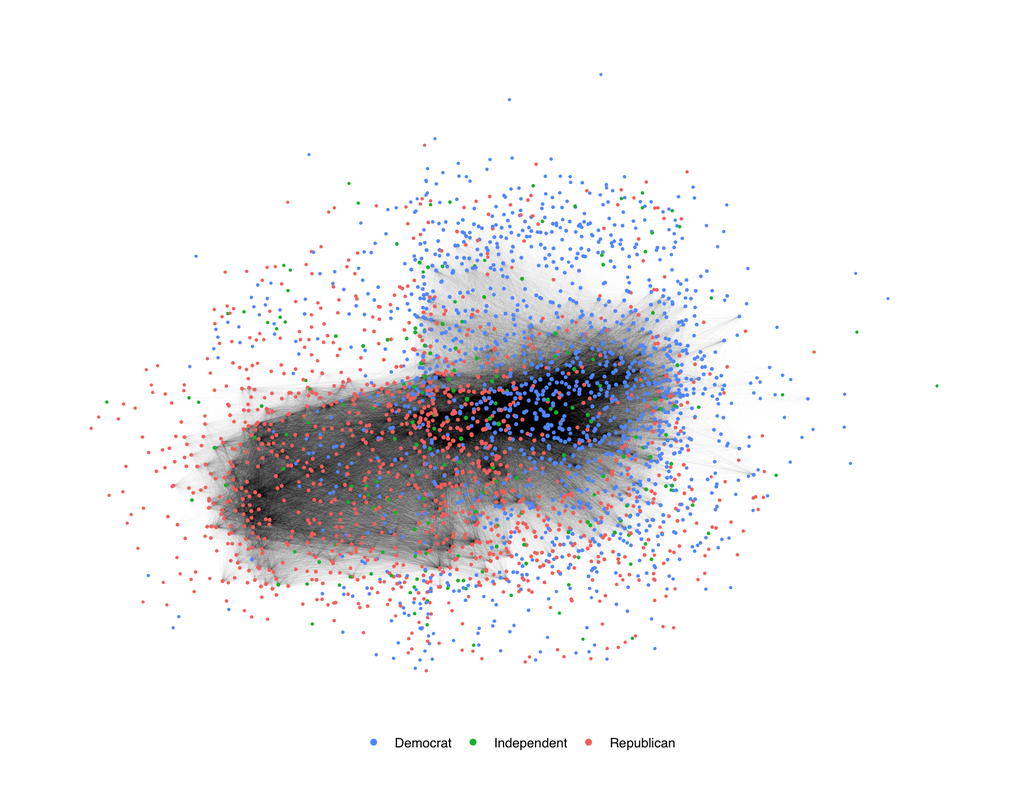

## Distribution of SSI by party

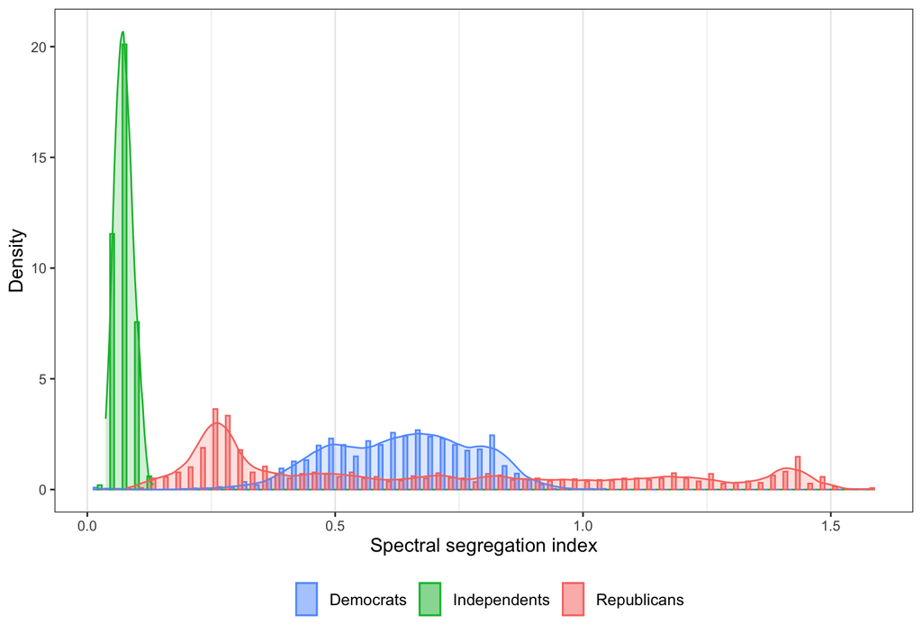

## Takeaways

- SSI shows interesting within- and between-party variation in segregation
- Can be used as individual-level variable for theory testing
- Data requirements:
  - List of sources used by respondents (more is better)
  - Party ID
- Can be directly compared to:
  - interpersonal (social) network segregation
  - other countries, media systems, etc.